# Solutions for 11/12: Multiple linear regression: exploring interaction

Notes and in-class exercises

# Data for exploration

```r
# Load packages and data
library(readr)
library(ggplot2)
library(dplyr)
cps <- read_csv("https://mac-stat.github.io/data/cps_2018.csv")
# Get data on just the management and transportation sectors
cps_sub <- cps %>%
    filter(industry %in% c("management", "transportation"))
```

## Exercise F: Wages across all industries

The plot below illustrates the relationship between wage and education for all of the industries in our `cps` dataset.

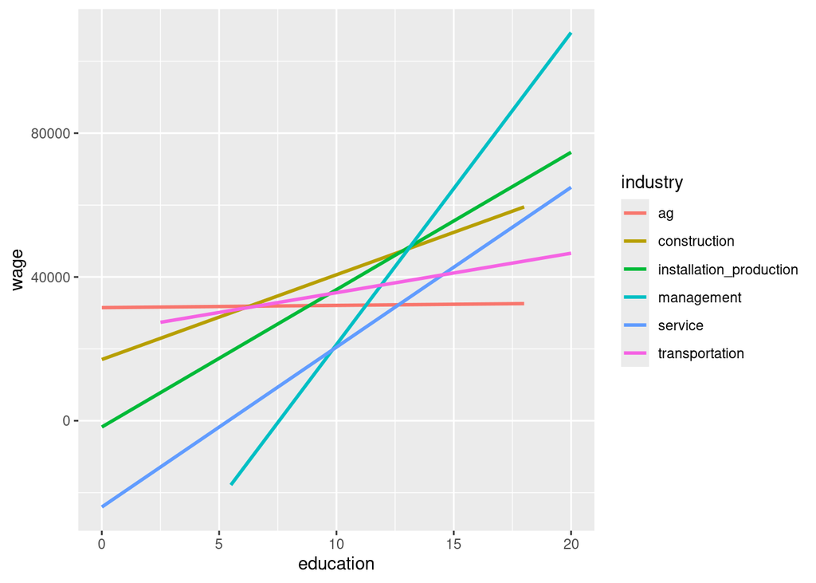

```r
# Plot
ggplot(cps, aes(y = wage, x = education, color = industry)) +
    geom_smooth(method = "lm", se = FALSE)
```

1. The industry-specific lines all have different slopes.
2. ag (first in alphabetical order)
3. This is a challenge! Compare your prediction to what you see when fitting the model in part d.

```r
# Fit an interaction model called wage_model
wage_model <- lm(wage ~ education*industry, data = cps)

# Display summarized model output
coef(summary(wage_model))
```

```
                                              Estimate Std. Error     t value
(Intercept)                                31475.87521  22370.504  1.40702574
education                                     61.95396   2039.257  0.03038065
industryconstruction                      -14427.01189  25740.953 -0.56046923
industryinstallation_production           -33208.72359  25346.017 -1.31021469
industrymanagement                        -97066.48097  23305.235 -4.16500759
industryservice                           -55462.76415  23229.134 -2.38763810
industrytransportation                     -6834.25066  27495.549 -0.24855844
education:industryconstruction              2295.51232   2297.659  0.99906577
education:industryinstallation_production   3759.05906   2244.792  1.67456904
education:industrymanagement                8616.31984   2080.190  4.14208220
education:industryservice                   4384.72036   2092.523  2.09542317
education:industrytransportation            1036.09210   2409.093  0.43007562
                                              Pr(>|t|)
(Intercept)                               1.594509e-01
education                                 9.757641e-01
industryconstruction                      5.751720e-01
industryinstallation_production           1.901533e-01
industrymanagement                        3.139604e-05
industryservice                           1.697551e-02
industrytransportation                    8.037075e-01
education:industryconstruction            3.177870e-01
education:industryinstallation_production 9.405013e-02
education:industrymanagement              3.470009e-05
education:industryservice                 3.615851e-02
education:industrytransportation          6.671499e-01
```

5. In the **management** industry, wages increase the *most* per year of education. The increase is 61.95396 + 8616.31984 = $8678.274 per year. That is, every additional year of education is associated with an average increase of $8678.27 in yearly wages in the management industry.
6. In the **ag**riculture industry, wages increase the *least* per year of education. The increase is $61.95 per year. That is, every additional year of education is associated with an average increase of $61.95 in yearly wages in the ag industry.

# Data for exercises

```r
# Load packages and import data
library(ggplot2)
library(dplyr)
library(readr)
library(stringr)
library(tidyr)

bikes <- read_csv("https://mac-stat.github.io/data/bikeshare.csv")

# A little bit of data wrangling code - let's not focus on this for now
campaigns <- read_csv("https://mac-stat.github.io/data/campaign_spending.csv") %>%
  dplyr::select(wholename, district, votes, incumbent, spending) %>%
  mutate(spending = spending / 1000) %>%
  filter(!is.na(spending))

# A little bit of data wrangling code - let's not focus on this for now
cars <- read_csv("https://mac-stat.github.io/data/used_cars.csv") %>%
  mutate(milage = milage %>% str_replace(",","") %>% str_replace(" mi.","") %>% as.numeric(),
         price = price %>% str_replace(",","") %>% str_replace("\\$","") %>% as.numeric(),
         age = 2025 - model_year) # 2025 so that yr. 2024 cars are one year old
```

## Exercise 1: Translating scientific questions into statistical questions

1. From this question, the only clear variable that should be involved in our analysis/exploration is spending. We could first begin by providing numerical and visual summaries of campaign spending. We could also look at whether spending varies by district, number of votes, or incumbency status. This would give us a broad idea of how campagin spending may vary across the variables we access to in our data.
2. We can estimate the average associated increase in number of votes per additional 1,000 Euros spent, via a simple linear regression model. The model statement that allows us to answer this question is given by

$$E[votes | spending] = \beta_0 + \beta_1 spending$$
The regression coefficient we would interpret to answer this question is the coefficient fpr `spending`, which in this case is $\beta_1$.

3. We are interested in the how the association between average number of votes and campaign spending varies by incumbency status. The model statement that allows us to answer this question is given by

$$E[votes | spending, incumbent] = \beta_0 + \beta_1 spending + \beta_2 incumbent + \beta_3 spending:incumbent$$

(note that the order in which you put spending and incumbent status does not matter!)

The regression coefficient we would interpret to answer this question is the interaction coefficient, which in this case is $\beta_3$.

## Exercise 2: Visualizing Interaction

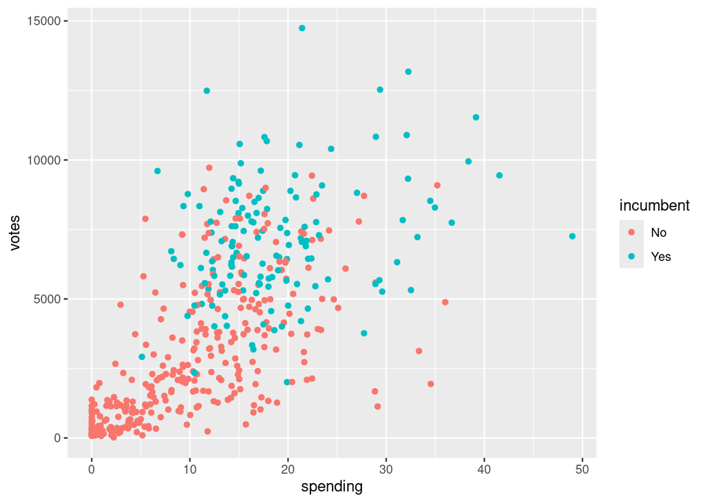

```r
# Visualization
campaigns %>%
  ggplot(aes(spending, votes, col = incumbent)) +
  geom_point()
```

2. In general, the more a candidate spends on their campaign, the more votes they receive. Incumbents appear to spend more than challengers on their campaigns, typically. The impact of spending on votes appears to be greater for challengers than for incumbents, in that more spending may lead to *even* more votes for challengers, than it would for incumbents.
3. I think including an interaction term between incumbent status and spending would be meaningful, since the relationship between spending and votes does seem to vary by incumbent status. In particular, note that the lines on the visualization are *not parallel*. Parallel lines imply that there is no interaction present, so the further the lines are from parallel, the more intense (in some sense) the interaction term.

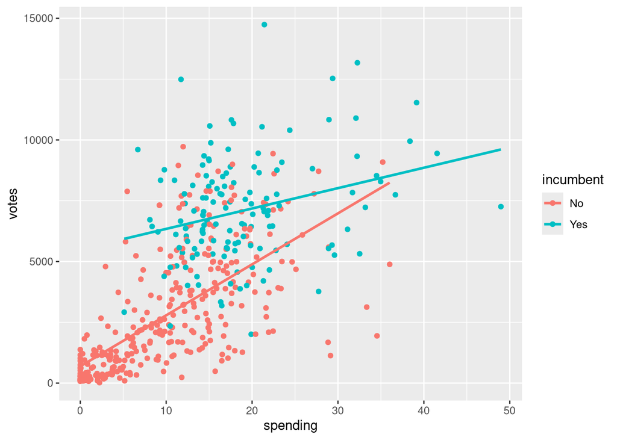

```r
# Visualization with lines of best fit
campaigns %>%
  ggplot(aes(spending, votes, col = incumbent)) +
  geom_point() +
  geom_smooth(method = "lm", se = FALSE)
```

## Exercise 3: Fitting and interpreting models with interaction terms

```r
# Model with interaction term
lm(data = campaigns, votes ~ spending*incumbent)
```

```
Call:
lm(formula = votes ~ spending * incumbent, data = campaigns)

Coefficients:
          (Intercept)               spending           incumbentYes
                690.5                  209.7                 4813.9
spending:incumbentYes
               -125.9
```

> (Intercept): 690.5

> incumbentYes: 4813.9

> spending: 209.7

> incumbentYes:spending: -125.9
- For incumbents:

$$E[votes | spending] = 690 + 4813.9 + 209.7 * spending - 125.9 * spending = 5503.9 + 83.8 * spending$$

- For challengers:

$$E[votes | spending] = 690.5 + 209.7 * spending$$

3. On average, we expect the difference in number of votes between incumbents and challengers to be 4813.9, for campaigns where no money is spent. This is likely not a scientifically meaningful estimate since there are very few campaigns where no money is spent. However, such campaigns *do* exist, so I would say this one could be meaningful in certain contexts, if not broadly!
4. On average, we expect an increase in spending by 1,000 euros to be associated with an increase in number of votes by 210, for challengers. On average, we expect an increase in spending by 1,000 euros to be associated with an increase in number of votes by 84, for incumbents.
5. I think the interaction term is meaningful when predicting number of votes, since 84 and 210 are relatively different numbers! The interaction term gives us the additional information that spending has less of an effect on number of votes for incumbents than it does for challengers, which is particularly meaningful if you are a campaign manager!

## Exercise 4: Interactions between two categorical variables

```r
# Creating user variable, don't worry about syntax!
new_bikes <- bikes %>%
  dplyr::select(riders_casual, riders_registered, weekend, temp_actual) %>%
  pivot_longer(cols = riders_casual:riders_registered, names_to = "user",
               names_prefix = "riders_", values_to = "rides") %>%
  mutate(weekend = factor(weekend))
```

> `weekend`: categorical (binary)

> `user`: categorical (binary)

> `rides`: quantitative

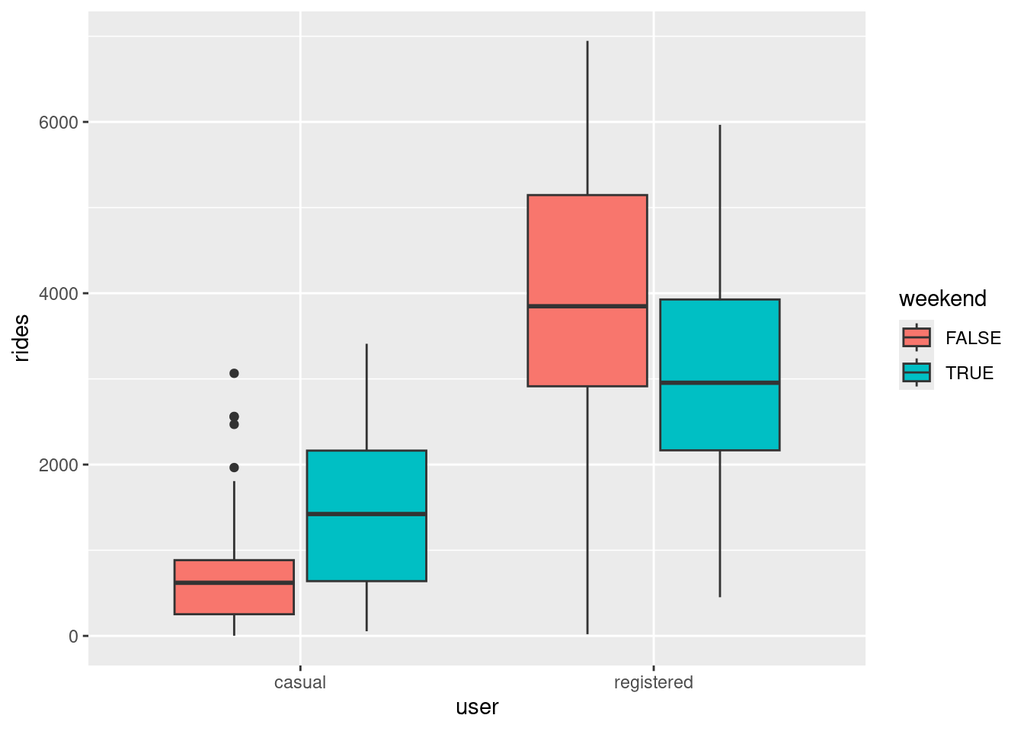

```r
# Visualization
new_bikes %>%
  ggplot(aes(y = rides, user, fill = weekend)) +
  geom_boxplot()
```

3. The relationship between ridership and weekend status does not appear to be the same for registered and casual users. Specifically, casual users have higher median riders on weekends, whereas the opposite is true for registered users.

```r
# Multiple linear regression model
lm(data = new_bikes, rides ~ user * weekend)
```

```
Call:
lm(formula = rides ~ user * weekend, data = new_bikes)

Coefficients:
               (Intercept)              userregistered
                     625.0                      3300.5
               weekendTRUE  userregistered:weekendTRUE
                     776.7                     -1714.4
```

5. On average, we expect there to be 777 more rides on weekends compared to non-weekends, for casual riders. On average, we expect there to be 938 (776.7 - 1714.4, rounded) *less* rides on weekends compared to non-weekends, for registered riders.

**Note**: There are lots of ways you could correctly interpret the interaction term here! You could do it one sentence, you could do it in four (one for each unique group defined by the two categorical variables), or you could compare users and registered riders for weekends, and then separately for non-weekends! All are valid options.

## Exercise 5: Interactions between two quantitative variables

Here we’ll explore the relationship between `price`, `milage`, and `age` of a used car. Below is a scatterplot of mileage vs. price, colored by age:

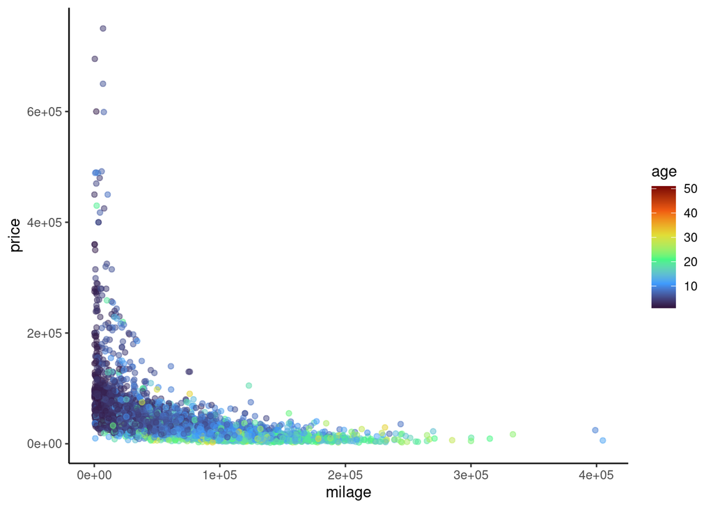

```r
cars %>%
  ggplot(aes(x = milage, y = price, col = age)) +
  geom_point(alpha = 0.5) + # make the points less opaque
  scale_color_viridis_c(option = "H") + # a fun, colorblind-friendly palette!
  theme_classic() # removes the gray background and grid
```

It’s a little difficult to tell what exactly is going on here. In particular, does the relationship between mileage and price vary with age of a used car? Let’s try adding some fitted lines for cars of different ages.

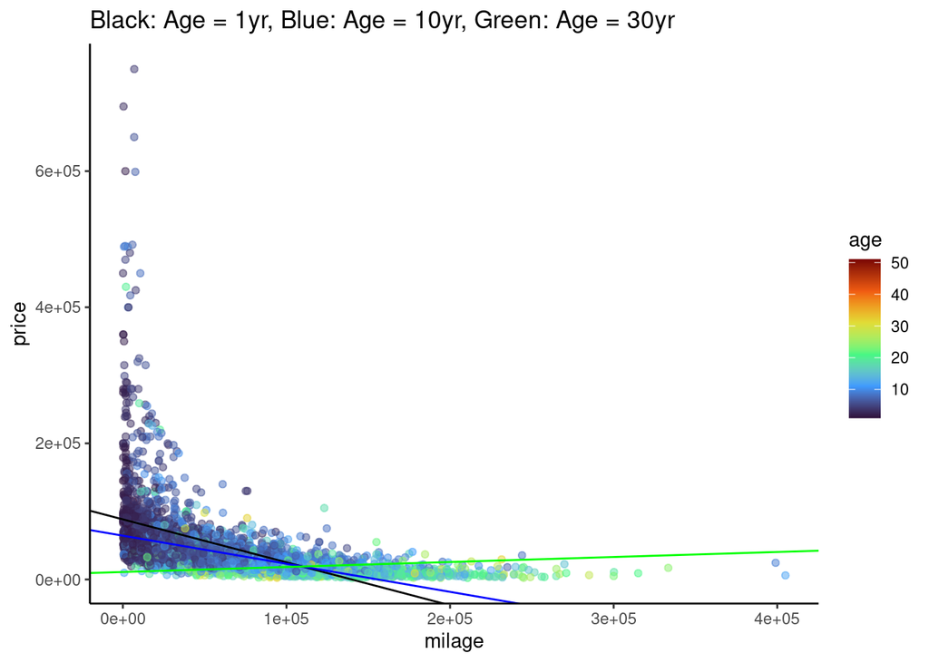

```r
# Ignore where the numbers in geom_abline() came from for now... we'll get there
cars %>%
  ggplot(aes(x = milage, y = price, col = age)) +
  geom_point(alpha = 0.5) +
  scale_color_viridis_c(option = "H") +
  theme_classic() +
  geom_abline(slope = -6.558e-01 + 2.431e-02, intercept = 9.096e+04 -2.665e+03, col = "black") +
  geom_abline(slope = -6.558e-01 + 10 * 2.431e-02, intercept = 9.096e+04 - 10 * 2.665e+03, col = "blue") +
  geom_abline(slope = -6.558e-01 + 30 * 2.431e-02, intercept = 9.096e+04 - 30 * 2.665e+03, col = "green") +
  ggtitle("Black: Age = 1yr, Blue: Age = 10yr, Green: Age = 30yr")
```

$$E[price | age, milage] = \beta_0 + \beta_1 milage + \beta_2 age + \beta_3 milage:age$$
* $\beta_0$: positive, since the intercept is the average price for a car with zero miles that is brand new.

- $\beta_1$: negative, since the more miles a new car has, the cheaper it should be
- $\beta_2$: negative, since the intercept of the lines seems to decrease with age (black -> blue -> green)
- $\beta_3$: positive, since the slope of the lines seems to increase with age (black -> blue -> green)

```r
# Multiple linear regression model

lm(data = cars, price ~ milage * age)
```

```
Call:
lm(formula = price ~ milage * age, data = cars)

Coefficients:
(Intercept)       milage          age   milage:age
  9.096e+04   -6.558e-01   -2.665e+03    2.431e-02
```

```r
# ... now do you see where the numbers in geom_abline() came from?
```

As before, we could choose distinct ages, and interpret the relationship between mileage and price for each of those groups separately. However, since age is *quantitative* and not *categorical*, this doesn’t quite give us the whole picture. Instead, we want to know how the relationship between mileage and price changes **for each additional year old** a car is. This is what the interaction coefficient estimates, when the interaction term is between two quantitative variables!

3. On average, we expect that an increase in mileage by 1 mile is associated with an additional increase in price by $0.0243 for each additional year old the car is.